# Halloween Candy

Alex Cagle

2023-05-11

```r
candy_file <- "candy-data.csv"

candy = read.csv(candy_file, row.names=1)
head(candy)
```

```
##              chocolate fruity caramel peanutyalmondy nougat crispedricewafer
## 100 Grand            1      0       1              0      0                1
## 3 Musketeers         1      0       0              0      1                0
## One dime             0      0       0              0      0                0
## One quarter          0      0       0              0      0                0
## Air Heads            0      1       0              0      0                0
## Almond Joy           1      0       0              1      0                0
##              hard bar pluribus sugarpercent pricepercent winpercent
## 100 Grand       0   1        0        0.732        0.860   66.97173
## 3 Musketeers    0   1        0        0.604        0.511   67.60294
## One dime        0   0        0        0.011        0.116   32.26109
## One quarter     0   0        0        0.011        0.511   46.11650
## Air Heads       0   0        0        0.906        0.511   52.34146
## Almond Joy      0   1        0        0.465        0.767   50.34755
```

> Q1. How many different candy types are in this dataset?

```r
nrow(candy)
```

```
## [1] 85
```

> Q2. How many fruity candy types are in the dataset?

```r
sum(candy$fruity)
```

```
## [1] 38
```

> Q: What are these fruity candy?

```r
rownames(candy[candy$fruity == 1, ])
```

```
##  [1] "Air Heads"                   "Caramel Apple Pops"
##  [3] "Chewey Lemonhead Fruit Mix"  "Chiclets"
##  [5] "Dots"                        "Dum Dums"
##  [7] "Fruit Chews"                 "Fun Dip"
##  [9] "Gobstopper"                  "Haribo Gold Bears"
## [11] "Haribo Sour Bears"           "Haribo Twin Snakes"
## [13] "Jawbusters"                  "Laffy Taffy"
## [15] "Lemonhead"                   "Lifesavers big ring gummies"
## [17] "Mike & Ike"                  "Nerds"
## [19] "Nik L Nip"                   "Now & Later"
## [21] "Pop Rocks"                   "Red vines"
## [23] "Ring pop"                    "Runts"
## [25] "Skittles original"           "Skittles wildberry"
## [27] "Smarties candy"              "Sour Patch Kids"
## [29] "Sour Patch Tricksters"       "Starburst"
## [31] "Strawberry bon bons"         "Super Bubble"
## [33] "Swedish Fish"                "Tootsie Pop"
## [35] "Trolli Sour Bites"           "Twizzlers"
## [37] "Warheads"                    "Welch's Fruit Snacks"
```

> Q3. What is your favorite candy in the dataset and what is it’s winpercent value? In other words, how often does my favorite candy win?

```r
candy["Snickers", ]$winpercent
```

```
## [1] 76.67378
```

> Q4. What is the winpercent value for “Kit Kat”?

```r
candy["Kit Kat", ]$winpercent
```

```
## [1] 76.7686
```

> Q5. What is the winpercent value for “Tootsie Roll Snack Bars”?

```r
candy["Tootsie Roll Snack Bars", ]$winpercent
```

```
## [1] 49.6535
```

```r
#install.packages('skimr')
library("skimr")
skim(candy)
```

Data summary

| Name | candy |
| --- | --- |
| Number of rows | 85 |
| Number of columns | 12 |
| _______________________ |  |
| Column type frequency: |  |
| numeric | 12 |
| ________________________ |  |
| Group variables | None |

**Variable type: numeric**

| skim_variable | n_missing | complete_rate | mean | sd | p0 | p25 | p50 | p75 | p100 | hist |
| --- | --- | --- | --- | --- | --- | --- | --- | --- | --- | --- |
| chocolate | 0 | 1 | 0.44 | 0.50 | 0.00 | 0.00 | 0.00 | 1.00 | 1.00 | ▇▁▁▁▆ |
| fruity | 0 | 1 | 0.45 | 0.50 | 0.00 | 0.00 | 0.00 | 1.00 | 1.00 | ▇▁▁▁▆ |
| caramel | 0 | 1 | 0.16 | 0.37 | 0.00 | 0.00 | 0.00 | 0.00 | 1.00 | ▇▁▁▁▂ |
| peanutyalmondy | 0 | 1 | 0.16 | 0.37 | 0.00 | 0.00 | 0.00 | 0.00 | 1.00 | ▇▁▁▁▂ |
| nougat | 0 | 1 | 0.08 | 0.28 | 0.00 | 0.00 | 0.00 | 0.00 | 1.00 | ▇▁▁▁▁ |
| crispedricewafer | 0 | 1 | 0.08 | 0.28 | 0.00 | 0.00 | 0.00 | 0.00 | 1.00 | ▇▁▁▁▁ |
| hard | 0 | 1 | 0.18 | 0.38 | 0.00 | 0.00 | 0.00 | 0.00 | 1.00 | ▇▁▁▁▂ |
| bar | 0 | 1 | 0.25 | 0.43 | 0.00 | 0.00 | 0.00 | 0.00 | 1.00 | ▇▁▁▁▂ |
| pluribus | 0 | 1 | 0.52 | 0.50 | 0.00 | 0.00 | 1.00 | 1.00 | 1.00 | ▇▁▁▁▇ |
| sugarpercent | 0 | 1 | 0.48 | 0.28 | 0.01 | 0.22 | 0.47 | 0.73 | 0.99 | ▇▇▇▇▆ |
| pricepercent | 0 | 1 | 0.47 | 0.29 | 0.01 | 0.26 | 0.47 | 0.65 | 0.98 | ▇▇▇▇▆ |
| winpercent | 0 | 1 | 50.32 | 14.71 | 22.45 | 39.14 | 47.83 | 59.86 | 84.18 | ▃▇▆▅▂ |

> Q6. Is there any variable/column that looks to be on a different scale to the majority of the other columns in the dataset?

Yes, the `winpercent` column is on a 0:100 scale and all others appear to be on a 0:1 scale.

> Q7. What do you think a zero and one represent for the candy$chocolate column?

A zero here means the candy is not classified as containing chocolate.

> Q8. Plot a histogram of winpercent values

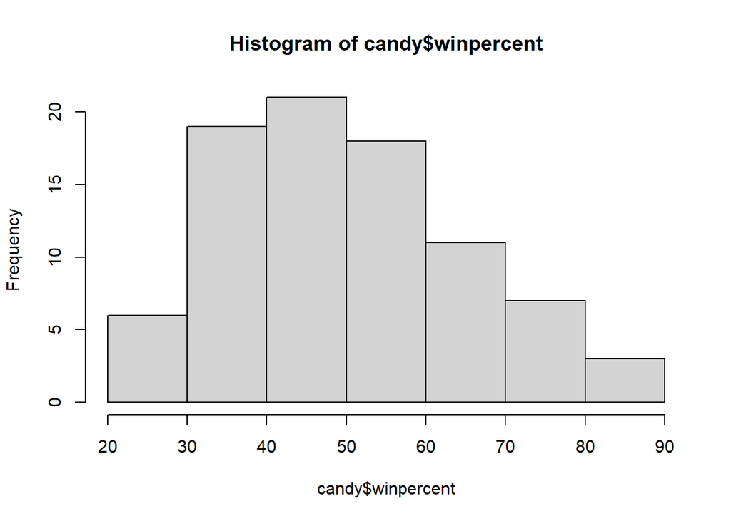

```r
hist(candy$winpercent)
```

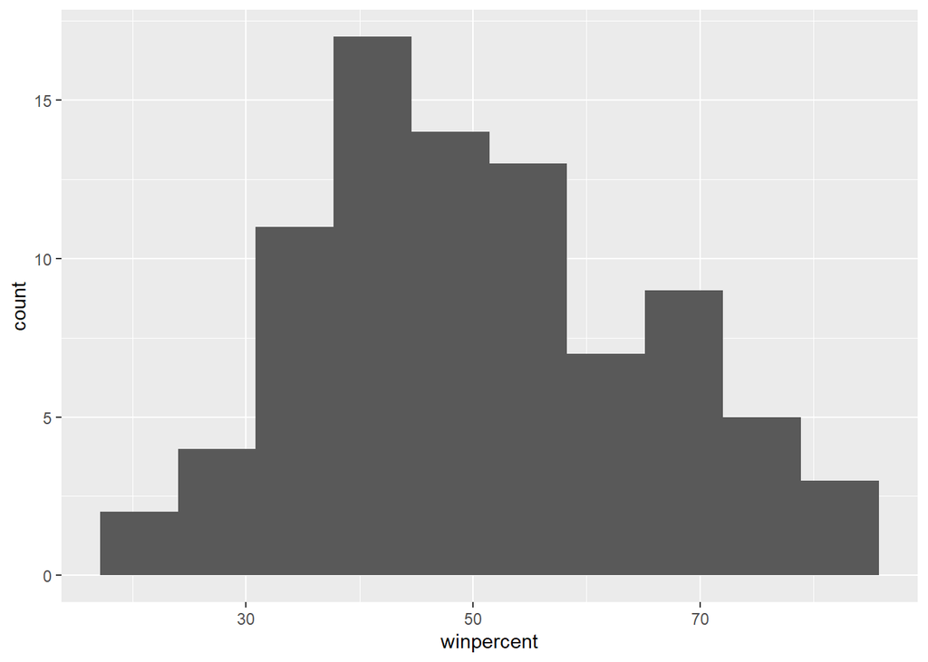

```r
library(ggplot2)
ggplot(candy) +
  aes(winpercent) +
  geom_histogram(bins=10)
```

> Q9. Is the distribution of winpercent values symmetrical?

No.

> Q10. Is the center of the distribution above or below 50%?

```r
mean(candy$winpercent)
```

```
## [1] 50.31676
```

> Q11. On average is chocolate candy higher or lower ranked than fruit candy?

To answer this, I need to subset the candy dataset to select only chocolate candy and then calculate the mean of these. Then, I need to do the same for fruity candy.

```r
# Filter/subset data to just get chocolate rows
chocolate.candy <- candy[as.logical(candy$chocolate), ]

# Get winpercent values
chocolate.winpercent <- chocolate.candy$winpercent

# Calculate the mean of winpercent values
mean(chocolate.winpercent)
```

```
## [1] 60.92153
```

```r
# Filter/subset data to just get fruity rows
fruity.candy <- candy[as.logical(candy$fruity), ]

# Get winpercent values
fruity.winpercent <- fruity.candy$winpercent

# Calculate the mean of winpercent values
mean(fruity.winpercent)
```

```
## [1] 44.11974
```

So, chocolate (60.92%) is more popular than fruity (44.11%).

> Q12. Is this difference statistically significant?

## Overall Candy Ranking

There is a base R function called `sort()` for sorting vectors of input.

```r
x <- c(5, 2, 10)

sort(x, decreasing = TRUE)
```

```
## [1] 10  5  2
```

There is a function related to `sort()` called `order()`, which gives us the order of indices.

```r
order(x)
```

```
## [1] 2 1 3
```

```r
x[ order(x) ]
```

```
## [1]  2  5 10
```

> Q13. What are the five least liked candy types in this set?

```r
ord <- order(candy$winpercent)
head(candy[ord,])
```

```
##                    chocolate fruity caramel peanutyalmondy nougat
## Nik L Nip                  0      1       0              0      0
## Boston Baked Beans         0      0       0              1      0
## Chiclets                   0      1       0              0      0
## Super Bubble               0      1       0              0      0
## Jawbusters                 0      1       0              0      0
## Root Beer Barrels          0      0       0              0      0
##                    crispedricewafer hard bar pluribus sugarpercent pricepercent
## Nik L Nip                         0    0   0        1        0.197        0.976
## Boston Baked Beans                0    0   0        1        0.313        0.511
## Chiclets                          0    0   0        1        0.046        0.325
## Super Bubble                      0    0   0        0        0.162        0.116
## Jawbusters                        0    1   0        1        0.093        0.511
## Root Beer Barrels                 0    1   0        1        0.732        0.069
##                    winpercent
## Nik L Nip            22.44534
## Boston Baked Beans   23.41782
## Chiclets             24.52499
## Super Bubble         27.30386
## Jawbusters           28.12744
## Root Beer Barrels    29.70369
```

> Q14. What are the top 5 all time favorite candy types out of this set?

```r
ord <- order(candy$winpercent, decreasing = TRUE)
head(candy[ord,])
```

```
##                           chocolate fruity caramel peanutyalmondy nougat
## Reese's Peanut Butter cup         1      0       0              1      0
## Reese's Miniatures                1      0       0              1      0
## Twix                              1      0       1              0      0
## Kit Kat                           1      0       0              0      0
## Snickers                          1      0       1              1      1
## Reese's pieces                    1      0       0              1      0
##                           crispedricewafer hard bar pluribus sugarpercent
## Reese's Peanut Butter cup                0    0   0        0        0.720
## Reese's Miniatures                       0    0   0        0        0.034
## Twix                                     1    0   1        0        0.546
## Kit Kat                                  1    0   1        0        0.313
## Snickers                                 0    0   1        0        0.546
## Reese's pieces                           0    0   0        1        0.406
##                           pricepercent winpercent
## Reese's Peanut Butter cup        0.651   84.18029
## Reese's Miniatures               0.279   81.86626
## Twix                             0.906   81.64291
## Kit Kat                          0.511   76.76860
## Snickers                         0.651   76.67378
## Reese's pieces                   0.651   73.43499
```

> Q15. Make a first barplot of candy ranking based on winpercent values.

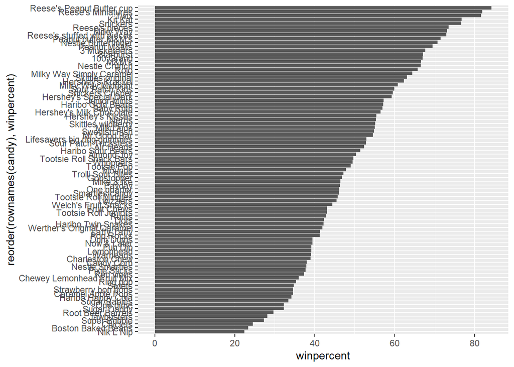

```r
ggplot(candy) +
  aes(winpercent, reorder( rownames(candy), winpercent)) +
  geom_col()
```

```r
my_cols=rep("black", nrow(candy))
my_cols[as.logical(candy$chocolate)] = "chocolate"
my_cols[as.logical(candy$bar)] = "brown"
my_cols[as.logical(candy$fruity)] = "pink"
```

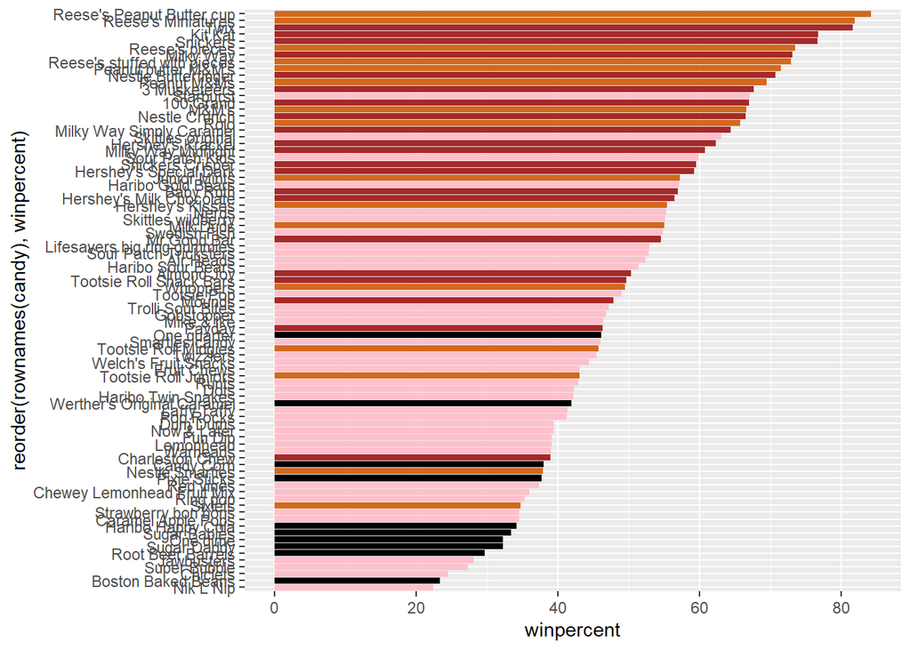

```r
ggplot(candy) +
  aes(winpercent, reorder(rownames(candy),winpercent)) +
  geom_col(fill=my_cols)
```

> Q17. What is the worst ranked chocolate candy?

Sixlets

> Q18. What is the best ranked fruit candy?

Starburst

## Taking a look at pricepercent

```r
my_cols[as.logical(candy$fruity)]
```

```
##  [1] "pink" "pink" "pink" "pink" "pink" "pink" "pink" "pink" "pink" "pink"
## [11] "pink" "pink" "pink" "pink" "pink" "pink" "pink" "pink" "pink" "pink"
## [21] "pink" "pink" "pink" "pink" "pink" "pink" "pink" "pink" "pink" "pink"
## [31] "pink" "pink" "pink" "pink" "pink" "pink" "pink" "pink"
```

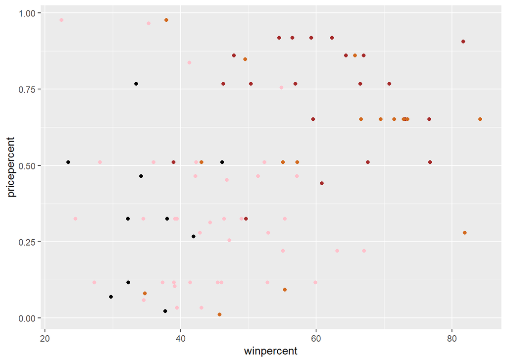

```r
ggplot(candy) +
  aes(winpercent, pricepercent, label=rownames(candy)) +
  geom_point(col=my_cols)
```

### Add some labels

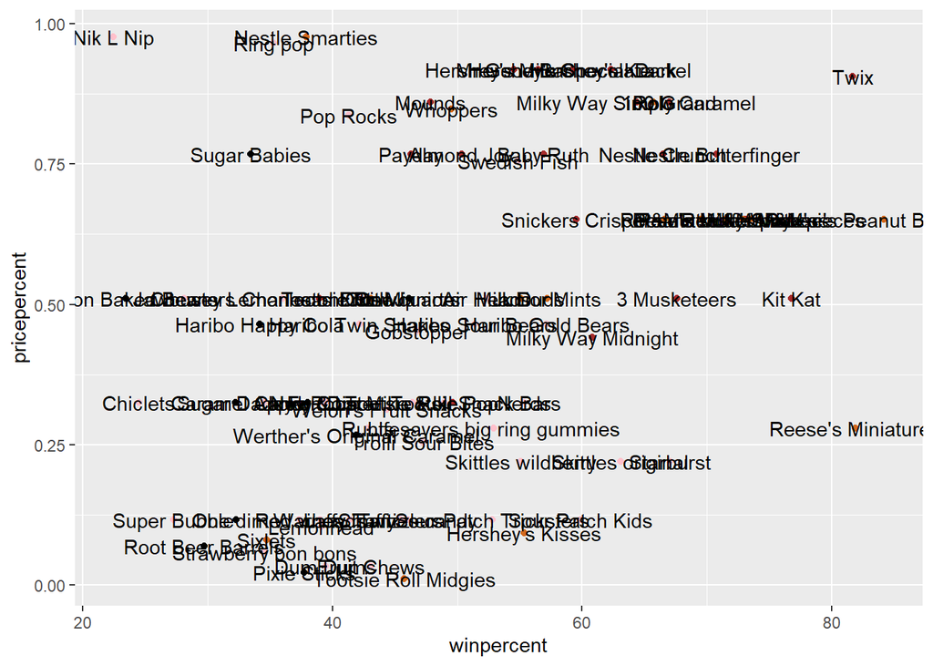

```r
ggplot(candy) +
  aes(winpercent, pricepercent, label = rownames(candy)) +
  geom_point(col = my_cols) +
  geom_text()
```

```r
#install.packages("ggrepel")
library(ggrepel)
```

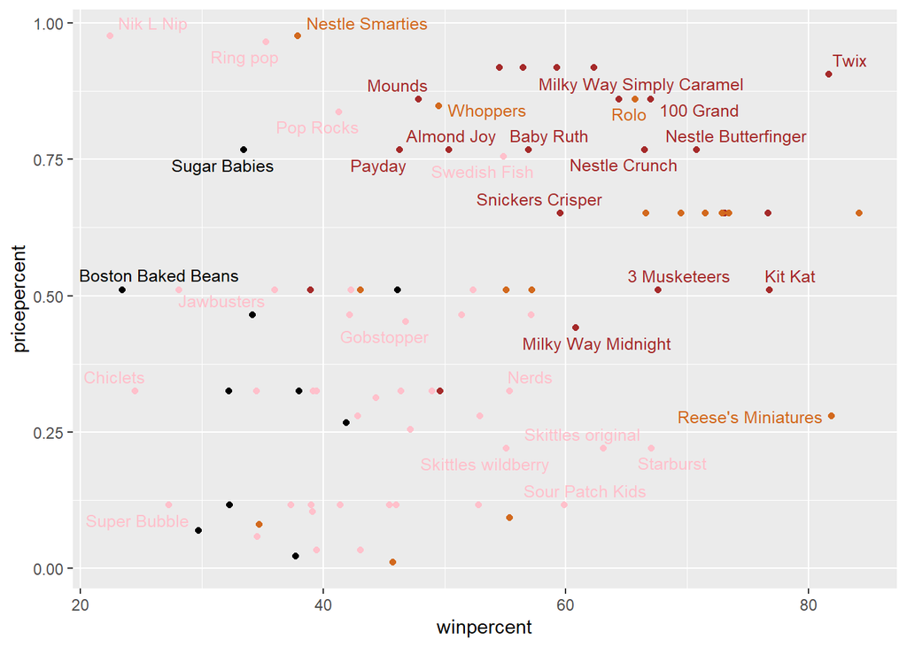

```r
# This will give us a cleaner graph

# How about a plot of pricepercent vs winpercent
ggplot(candy) +
  aes(winpercent, pricepercent, label=rownames(candy)) +
  geom_point(col=my_cols) +
  geom_text_repel(col=my_cols, size=3.3, max.overlaps = 5)
```

## Exploring the correlation structure

Pearson correlation goes between -1 and +1 with zero indicating no correlation and values close to one being very highly correlated.

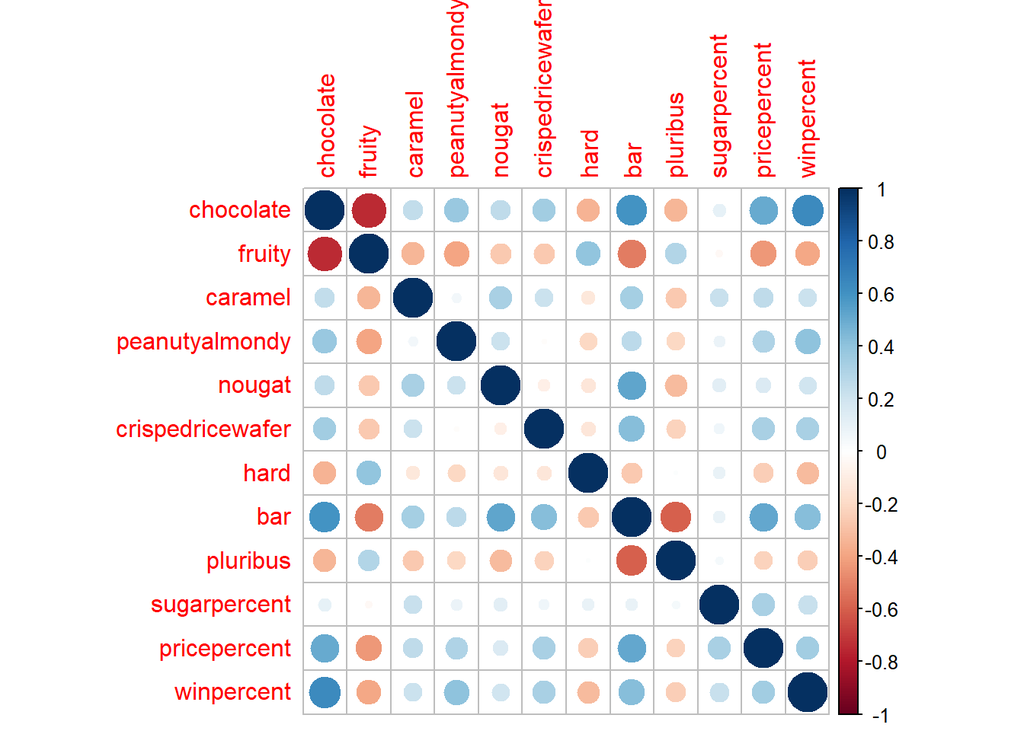

```r
library(corrplot)
cij <- cor(candy)
corrplot(cij)
```

> Q22. Examining this plot, what two variables are anti-correlated?

Chocolate and fruit and anti-correlated.

> Q23. What two variables are most positively correlated?

Chocolate and winpercent or chocolate and bar are the most positively correlated.

# 6. Principal Component Analysis

The base R function for PCA is called `prcomp()` and we can set “scale=TRUE/FALSE”.

```r
pca <- prcomp(candy, scale = TRUE)

summary(pca)
```

```
## Importance of components:
##                           PC1    PC2    PC3     PC4    PC5     PC6     PC7
## Standard deviation     2.0788 1.1378 1.1092 1.07533 0.9518 0.81923 0.81530
## Proportion of Variance 0.3601 0.1079 0.1025 0.09636 0.0755 0.05593 0.05539
## Cumulative Proportion  0.3601 0.4680 0.5705 0.66688 0.7424 0.79830 0.85369
##                            PC8     PC9    PC10    PC11    PC12
## Standard deviation     0.74530 0.67824 0.62349 0.43974 0.39760
## Proportion of Variance 0.04629 0.03833 0.03239 0.01611 0.01317
## Cumulative Proportion  0.89998 0.93832 0.97071 0.98683 1.00000
```

The main result of PCA - i.e. the new PC plot (projection of candy on our new PC axis) is contained in `pca$x`.

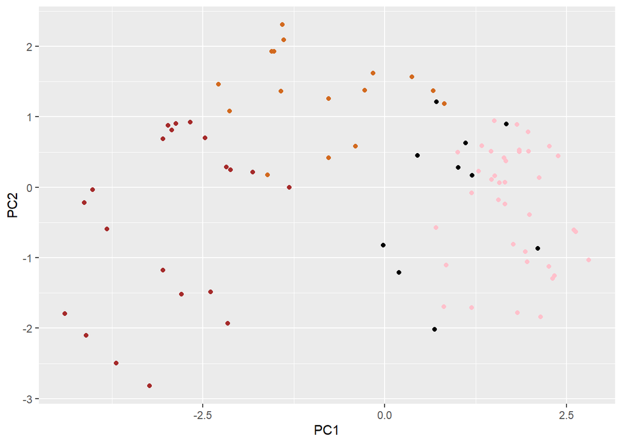

```r
pc <- as.data.frame(pca$x)

ggplot(pc) +
  aes(PC1, PC2, label = rownames(pc)) +
  geom_point(col = my_cols)
```

> Q24. What original variables are picked up strongly by PC1 in the positive direction? Do these make sense to you?

Fruity, hard, and pluribus

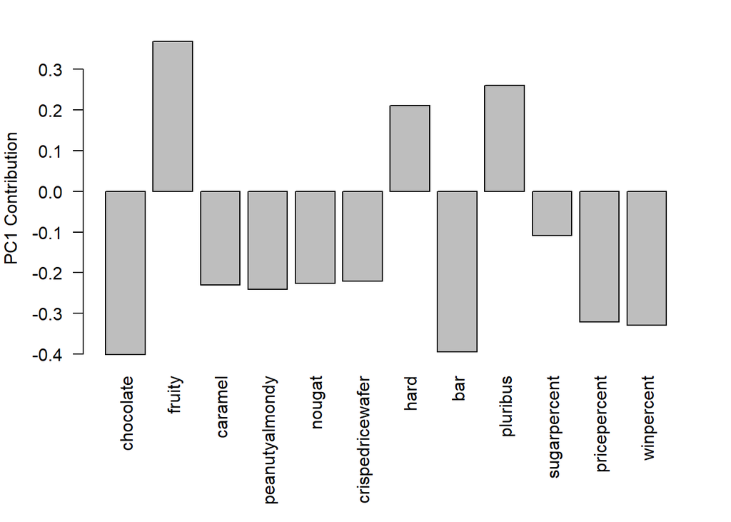

```r
par(mar=c(8, 4, 2, 2))
barplot(pca$rotation[,1], las=2, ylab="PC1 Contribution")
```